# Reproducible Research - Peer Assessment 1

BMCB

October 19, 2014

```r
library(knitr)
opts_chunk$set(fig.path = "figures/" )
```

This Rmarkdown document represents my submission for the Reproducible Research Coursera class’s peer assesment 1.

## Loading and preprocessing the data

The data is loaded with read.csv()

```r
df <- read.csv("activity.csv", stringsAsFactors=FALSE)

# convert to daily totals
daily_steps_df <- aggregate(steps ~ date, data=df, sum)
```

## What is mean total number of steps taken per day?

The following R code chuck calculates the mean and median of the total steps per day, and outpust a histogram showing the total steps for days included in the dataset.

```r
mean(daily_steps_df$steps)
```

```
## [1] 10766
```

```r
median(daily_steps_df$steps)
```

```
## [1] 10765
```

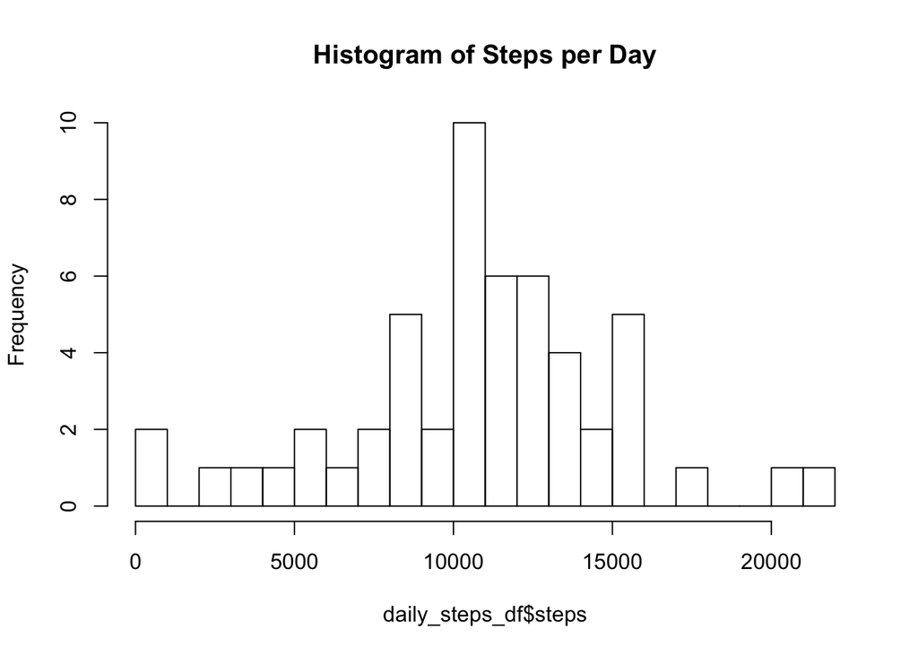

```r
hist(daily_steps_df$steps, breaks=20, main="Histogram of Steps per Day")
```

## What is the average daily activity pattern

The following R code chunk shows the daily pattern of steps across all 5 minute intervals, averaged across all days.

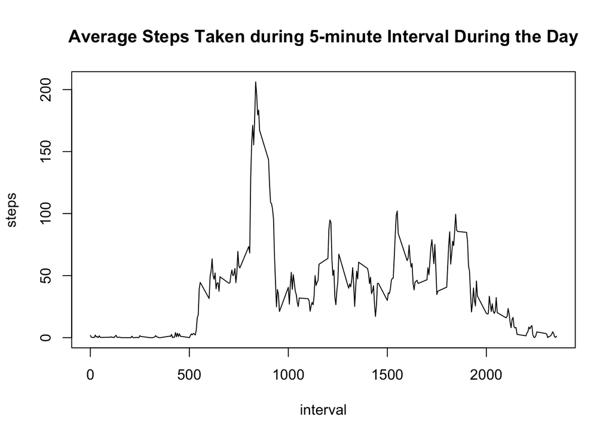

```r
# convert to interval averages
interval_steps_df <- aggregate(steps ~ interval, data=df, mean)

# plot pattern
plot(interval_steps_df, type="l", main="Average Steps Taken during 5-minute Interval During the Day")
```

```r
# Find max minute
interval_steps_df[which.max(interval_steps_df$steps),]
```

```
##     interval steps
## 104      835 206.2
```